# Bulk RNA-Sequencing REMI Tutorial

Alice Yu, Christine Yeh

# Getting started with REMI

```r
# install.packages("devtools")
# library(devtools)
# install_github("plevritis-lab/remi")
library(remi); library(knitr);library(ggplot2);library(ggalluvial)
```

# Read in data

Input file is a log-transformed bulk flow-sorted RNA-sequencing dataset from Gentles et al. *Genome Biology* (2020). Column names are labeled as samplename_celltype.

```r
data("u01adeno")
dat <- u01adeno
```

# Running REMI

There is a built in filtering step for REMI where users can choose to threshold their genes based on quantiles. The number 4 represents the number of bins the data is separated into. Genes in the lowest expression quantile will be removed. Users can also turn off the filtering option (filter = F), but setupData needs to run in order to make a REMI object for the algorithm. Note: the run time of REMI is proportional to the number of cell types of interest.

```r
# list of cell types user wants to analyze
celltypes <- c("I", "E", "F", "M")
# Create REMI object
exp.list <- setupData(dat, celltypes, 4, filter=T)
# RUNNING REMI
remi.obj <- remi(exp.list)
```

```
## Building LR network
##
## Step 1/3: Expanding LR pairs across all cell types
## [1] "I"
## [1] "E"
## [1] "F"
## [1] "M"
##
##  Total 6187104 LR Combos to Search
## Step 2/3: Calculating edge weight
## Step 3/3: Creating graph object
## Detecting communities
## All communities are larger than sample size
##
## All communities are larger than sample size
## 21 communities identified
##
##  Estimating activated LR pairs
## Removing conditionally independent edges within communities
##
## Removing conditionally independent edges between communities
```

# REMI Output

REMI interactome table

```r
kable(head(remi.obj$interactome, 5), digits = 5)
```

| ligand | receptor | sending | receiving | weight | cor | commnum | lambda |
| --- | --- | --- | --- | --- | --- | --- | --- |
| A2M | LRP1 | I | I | 0.41 | 0.87 | 1 | 0.0919296535030931 |
| C1QB | LRP1 | I | I | 0.39 | 0.86 | 1 | 0.0919296535030931 |
| PSAP | LRP1 | I | I | 0.38 | 0.84 | 1 | 0.0919296535030931 |
| SERPINA1 | LRP1 | I | I | 0.38 | 0.84 | 1 | 0.0919296535030931 |
| SERPING1 | LRP1 | I | I | 0.23 | 0.64 | 1 | 0.0919296535030931 |

Plotting option #1

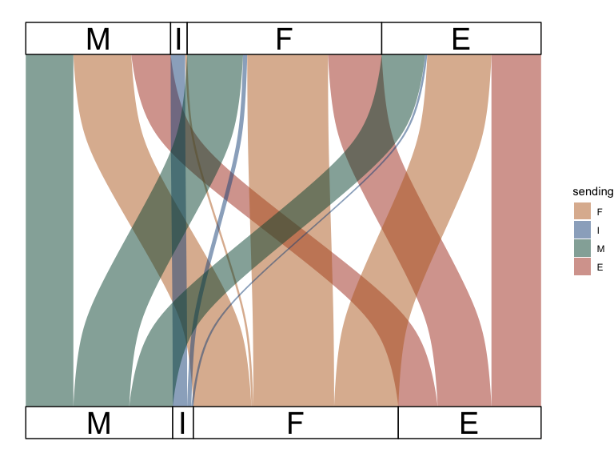

```r
# Defining colors for each cell type
grid.col <- c("F" = '#BB6A23',
              "I" = "#195188",
              "M" = "#00503C",
              "E" = "#AC371F")
# Plotting an alluvial plot showing proportion of cell types interacting
REMIPlot(remi.obj,
         type="alluvial",
         grid.col=grid.col)
```

Plotting option #2

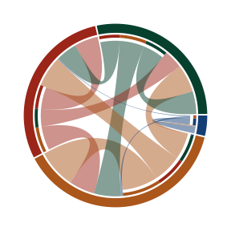

```r
# Plotting a chord diagram showing proportion of cell types interacting
REMIPlot(remi.obj,
         type="chord",
         grid.col=grid.col)
```

# Calculate significance of an edge

Enter in ligand and receptor of choice and which community number the pair is located in. The p-value is calculated with respect to the community. Please add cell type of ligand into ligand name (celltype_ligand) and cell type of receptor into receptor name (celltype_receptor) as input. Note: this step may take a while and we recommend only running it for LR pairs of interest.

```r
#pval <- calculateSignificance(remi.obj,
                              # l.chosen="F_CTGF",
                              # r.chosen="F_LRP6",
                              # comm.chosen="50")
```